# 11 Workshop GEE and GLMM

Xanthe Walker

2025-08-08

## Introduction

Reminder on “family” in GLMs/GEEs: Setting a family picks a link and mean–variance relationship (e.g., Poisson: log link, Var=μ). It’s a modeling framework for the mean; GEE then uses a working correlation structure for within-cluster correlation and robust (sandwich) SEs.

## 1. Generalized Estimating Equations

In this part, we’ll fit Generalized Estimating Equations (GEE) to repeated count data. GEE is a great option when you:

- have correlated observations (e.g., repeated measures within fields),
- want population-averaged (marginal) effects rather than subject-specific effects, and
- don’t want to fully specify random effects or a full likelihood.

We’ll use time series of aquatic bird species richness recorded in California rice fields. Our questions:

- Does richness vary with management type (flooding vs. not), water depth, and field size?
- What correlation structure best reflects within-field temporal correlation (AR-1 vs exchangeable vs independence)?
- How do results change across structures, and what does QIC say?

### Load and restructure data

```r
# Load data (adjust path if needed)
RFBirds <- read.csv("../../Data files/RiceFieldBirds.csv")

# Species richness across columns 8:56 (presence > 0) as given in notes
RFBirds$Richness <- rowSums(RFBirds[, 8:56] > 0)

# Factors and transforms
RFBirds$fField   <- factor(RFBirds$FIELD)
RFBirds$fSptreat <- factor(RFBirds$SPTREAT)   # management/flooding treatment
RFBirds$LA       <- log(RFBirds$AREA)         # log field area
RFBirds$DEPTH2   <- RFBirds$DEPTH^2           # optional nonlinearity

# Quick check
summary(RFBirds[, c("Richness", "DEPTH", "AREA")])
```

```
##     Richness          DEPTH            AREA
##  Min.   : 0.000   Min.   : 0.00   Min.   : 3.360
##  1st Qu.: 2.000   1st Qu.: 4.90   1st Qu.: 4.010
##  Median : 4.000   Median :14.85   Median : 4.500
##  Mean   : 4.309   Mean   :14.45   Mean   : 7.064
##  3rd Qu.: 6.000   3rd Qu.:20.75   3rd Qu.: 7.750
##  Max.   :14.000   Max.   :40.00   Max.   :19.140
```

```r
length(unique(RFBirds$fField))
```

```
## [1] 11
```

### Plot richness over time by field

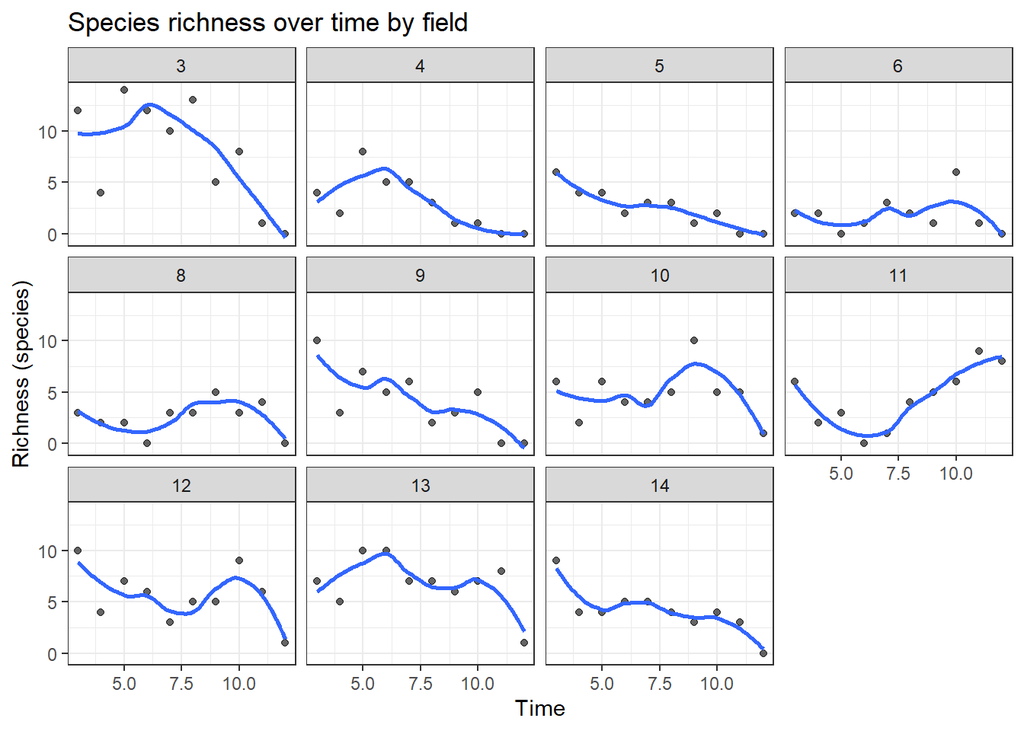

```r
RFBirds %>%
  ggplot(aes(Time, Richness)) +
  geom_point(alpha = 0.6) +
  geom_smooth(se = FALSE) +
  facet_wrap(~ fField) +
  theme_bw() +
  labs(title = "Species richness over time by field",
       y = "Richness (species)")
```

> Design: repeated measures within fields ⇒ we must account for within-field correlation.

### Fit a GEE

We start with a Poisson GEE for richness with a log link and cluster on `fField`. We include log area (LA), treatment, and depth. (You can test a curvature with `DEPTH2.`)

```r
gee_ar1 <- geeglm(
  Richness ~ LA + fSptreat + DEPTH,
  id      = fField,
  data    = RFBirds,
  family  = poisson,
  corstr  = "ar1"   # AR(1): closer time points more correlated
)
summary(gee_ar1)
```

```
##
## Call:
## geeglm(formula = Richness ~ LA + fSptreat + DEPTH, family = poisson,
##     data = RFBirds, id = fField, corstr = "ar1")
##
##  Coefficients:
##                Estimate   Std.err   Wald Pr(>|W|)
## (Intercept)    0.374841  0.268441  1.950   0.1626
## LA             0.567641  0.109841 26.707 2.37e-07 ***
## fSptreatrlfld -0.315674  0.167511  3.551   0.0595 .
## DEPTH          0.008375  0.005437  2.373   0.1235
## ---
## Signif. codes:  0 '***' 0.001 '**' 0.01 '*' 0.05 '.' 0.1 ' ' 1
##
## Correlation structure = ar1
## Estimated Scale Parameters:
##
##             Estimate Std.err
## (Intercept)    1.873  0.2375
##   Link = identity
##
## Estimated Correlation Parameters:
##       Estimate Std.err
## alpha   0.3782 0.06686
## Number of clusters:   11  Maximum cluster size: 10
```

> *Why AR-1?* Biological reasoning: counts in a field at time s likely depend on those at s−1 (and less so on s−2, …). This favors AR-1 over exchangeable (equal correlation for all lags) or independence. Unstructured is rarely practical with sparse time series per field.

### Compare correlation structures

We refit the same mean model but vary the working correlation: AR-1, exchangeable, independence.

```r
gee_exch <- geeglm(Richness ~ LA + fSptreat + DEPTH,
                   id = fField, data = RFBirds,
                   family = poisson, corstr = "exchangeable")

gee_ind  <- geeglm(Richness ~ LA + fSptreat + DEPTH,
                   id = fField, data = RFBirds,
                   family = poisson, corstr = "independence")

tab_model(gee_ar1, gee_exch, gee_ind)
```

|  | Richness |  |  | Richness |  |  | Richness |  |  |
| --- | --- | --- | --- | --- | --- | --- | --- | --- | --- |
| Predictors | Incidence Rate Ratios | CI | p | Incidence Rate Ratios | CI | p | Incidence Rate Ratios | CI | p |
| (Intercept) | 1.45 | 0.86 – 2.46 | 0.163 | 1.39 | 0.83 – 2.34 | 0.212 | 1.44 | 0.85 – 2.43 | 0.172 |
| LA | 1.76 | 1.42 – 2.19 | **<0.001** | 1.79 | 1.47 – 2.20 | **<0.001** | 1.78 | 1.44 – 2.20 | **<0.001** |
| fSptreat [rlfld] | 0.73 | 0.53 – 1.01 | 0.059 | 0.75 | 0.54 – 1.03 | 0.077 | 0.74 | 0.54 – 1.02 | 0.065 |
| DEPTH | 1.01 | 1.00 – 1.02 | 0.123 | 1.01 | 1.00 – 1.02 | 0.129 | 1.01 | 1.00 – 1.02 | 0.171 |
| N | 11 <sub>fField</sub> |  |  | 11 <sub>fField</sub> |  |  | 11 <sub>fField</sub> |  |  |
| Observations | 110 |  |  | 110 |  |  | 110 |  |  |

You should see very similar coefficients and slightly different SEs across structures (GEE is robust to misspecified correlation for the mean estimates).

### Compare with QIC

GEE doesn’t provide AIC. Use QIC to compare working correlation structures for a given mean model.

```r
# Compute/compare QIC
QIC(gee_ar1)
```

```
##       QIC      QICu Quasi Lik       CIC    params      QICC
##   -486.95   -489.13    248.56      5.09      4.00   -474.95
```

```r
QIC(gee_exch)
```

```
##       QIC      QICu Quasi Lik       CIC    params      QICC
##  -487.115  -489.217   248.609     5.051     4.000  -475.115
```

```r
QIC(gee_ind)
```

```
##       QIC      QICu Quasi Lik       CIC    params      QICC
##  -487.022  -489.277   248.639     5.128     4.000  -480.355
```

> QICs are identical or nearly so, pick the simplest (often independence) or the one best supported by biology (often AR-1 for time series).

### Model Diagnostics

GEE diagnostics are more limited than GLM/GLMM. There’s no exact DHARMa equivalent for geeglm, and residuals can be hard to interpret. Still, some simple checks help:

- Pearson residuals vs fitted (look for structure or extreme outliers)
- QQ-plot of Pearson residuals (purely heuristic)
- Within-cluster residual patterns over time

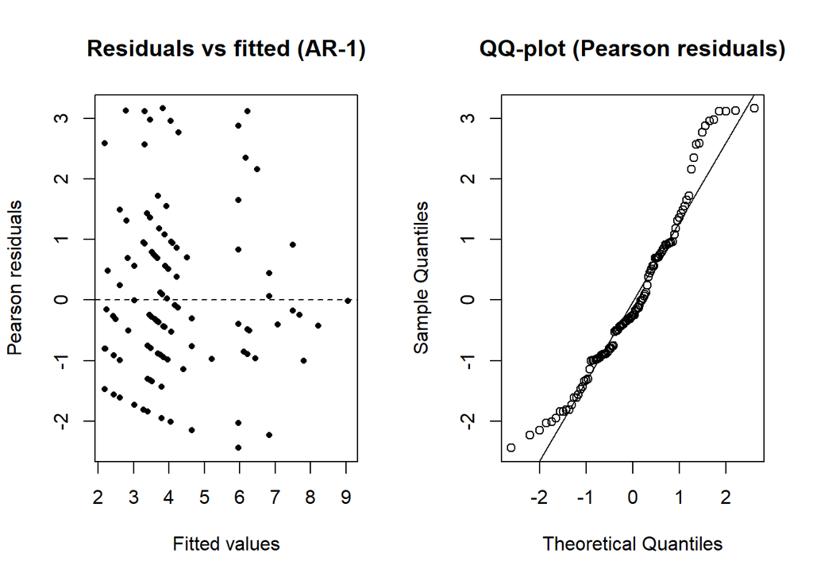

```r
# Pearson residuals & fitted
fit_ar1 <- predict(gee_ar1, type = "response")
res_ar1 <- residuals(gee_ar1, type = "pearson")

par(mfrow = c(1, 2))
plot(fit_ar1, res_ar1, pch = 16, cex = 0.7,
     xlab = "Fitted values", ylab = "Pearson residuals",
     main = "Residuals vs fitted (AR-1)")
abline(h = 0, lty = 2)
qqnorm(res_ar1, main = "QQ-plot (Pearson residuals)"); qqline(res_ar1)
```

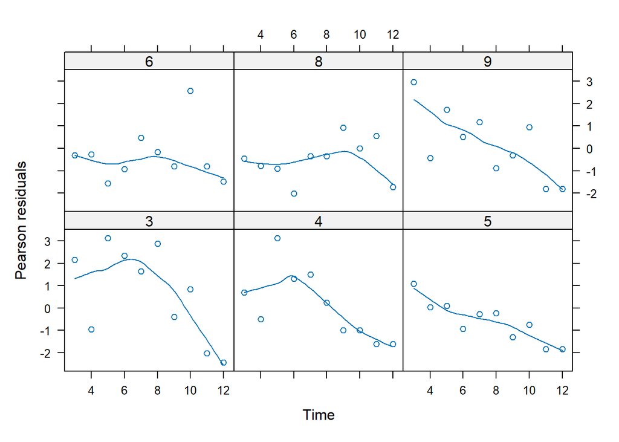

```r
par(mfrow = c(1, 1))

# Residuals over time within a couple of example fields
example_fields <- head(levels(RFBirds$fField), 6)
RFBirds$pearson_res <- res_ar1

xyplot(pearson_res ~ Time | fField, data = subset(RFBirds, fField %in% example_fields),
       type = c("p", "smooth"), layout = c(3, 2),
       ylab = "Pearson residuals", xlab = "Time")
```

> These checks are heuristic. For binomial GEE, plots often look worse even for acceptable fits. Focus on gross deviations rather than perfect normality.

### Optional refinements

*Overdispersion:* Poisson with robust SEs is typically fine under GEE, but if overdispersion is strong, consider adding predictors (e.g., DEPTH2) or switching to a quasi-Poisson GEE (family = quasipoisson) recognizing that QIC comparisons get tricky.

*Offsets vs covariates:* If you want a rate per area, use `offset(LA)` instead of `LA` as a covariate.

```r
# Example with an offset for area (rate of richness per area unit)
gee_ar1_off <- geeglm(Richness ~ fSptreat + DEPTH,
                      offset = LA,
                      id = fField, data = RFBirds,
                      family = poisson, corstr = "ar1")
summary(gee_ar1_off)
```

```
##
## Call:
## geeglm(formula = Richness ~ fSptreat + DEPTH, family = poisson,
##     data = RFBirds, offset = LA, id = fField, corstr = "ar1")
##
##  Coefficients:
##               Estimate  Std.err Wald Pr(>|W|)
## (Intercept)   -0.43716  0.24791 3.11    0.078 .
## fSptreatrlfld -0.49780  0.22437 4.92    0.027 *
## DEPTH          0.00730  0.00548 1.77    0.183
## ---
## Signif. codes:  0 '***' 0.001 '**' 0.01 '*' 0.05 '.' 0.1 ' ' 1
##
## Correlation structure = ar1
## Estimated Scale Parameters:
##
##             Estimate Std.err
## (Intercept)     2.44   0.231
##   Link = identity
##
## Estimated Correlation Parameters:
##       Estimate Std.err
## alpha    0.483  0.0801
## Number of clusters:   11  Maximum cluster size: 10
```

```r
QIC(gee_ar1_off)
```

```
##       QIC      QICu Quasi Lik       CIC    params      QICC
##   -454.49   -459.73    232.86      5.62      3.00   -447.82
```

### Model selection and reduction

We will use a Wald tests via anova.geeglm to determine if reducing the model if justified.

```r
gee_ar1 <- geeglm(
  Richness ~ LA + fSptreat + DEPTH,
  id      = fField,
  data    = RFBirds,
  family  = poisson,
  corstr  = "ar1"   # AR(1): closer time points more correlated
)

gee_ar1_B <- geeglm(
  Richness ~ LA + fSptreat,
  id      = fField,
  data    = RFBirds,
  family  = poisson,
  corstr  = "ar1"   # AR(1): closer time points more correlated
)

gee_ar1_C <- geeglm(
  Richness ~ LA + DEPTH,
  id      = fField,
  data    = RFBirds,
  family  = poisson,
  corstr  = "ar1"   # AR(1): closer time points more correlated
)

gee_ar1_D <- geeglm(
  Richness ~ fSptreat + DEPTH,
  id      = fField,
  data    = RFBirds,
  family  = poisson,
  corstr  = "ar1"   # AR(1): closer time points more correlated
)



anova(gee_ar1, gee_ar1_B)  # Wald test for dropping DEPTH
```

```
## Analysis of 'Wald statistic' Table
##
## Model 1 Richness ~ LA + fSptreat + DEPTH
## Model 2 Richness ~ LA + fSptreat
##   Df   X2 P(>|Chi|)
## 1  1 2.37      0.12
```

```r
anova(gee_ar1, gee_ar1_C)  # Wald test for dropping fSptreat
```

```
## Analysis of 'Wald statistic' Table
##
## Model 1 Richness ~ LA + fSptreat + DEPTH
## Model 2 Richness ~ LA + DEPTH
##   Df   X2 P(>|Chi|)
## 1  1 3.55     0.059 .
## ---
## Signif. codes:  0 '***' 0.001 '**' 0.01 '*' 0.05 '.' 0.1 ' ' 1
```

```r
anova(gee_ar1, gee_ar1_D)  # Wald test for dropping LA
```

```
## Analysis of 'Wald statistic' Table
##
## Model 1 Richness ~ LA + fSptreat + DEPTH
## Model 2 Richness ~ fSptreat + DEPTH
##   Df   X2 P(>|Chi|)
## 1  1 26.7   2.4e-07 ***
## ---
## Signif. codes:  0 '***' 0.001 '**' 0.01 '*' 0.05 '.' 0.1 ' ' 1
```

```r
gee_ar1_final <- geeglm(
  Richness ~ LA,
  id      = fField,
  data    = RFBirds,
  family  = poisson,
  corstr  = "ar1"   # AR(1): closer time points more correlated
)
```

### Interpreting coefficients

For a log link, exponentiate coefficients to get multiplicative effects on the expected mean richness. These are also provided with the tab_model function

```r
exp(coef(gee_ar1_final))
```

```
## (Intercept)          LA
##        1.73        1.62
```

```r
tab_model(gee_ar1_final)
```

|  | Richness |  |  |
| --- | --- | --- | --- |
| Predictors | Incidence Rate Ratios | CI | p |
| (Intercept) | 1.73 | 1.01 – 2.97 | **0.046** |
| LA | 1.62 | 1.32 – 2.00 | **<0.001** |
| N <sub>fField</sub> | 11 |  |  |
| Observations | 110 |  |  |

### Plot model results

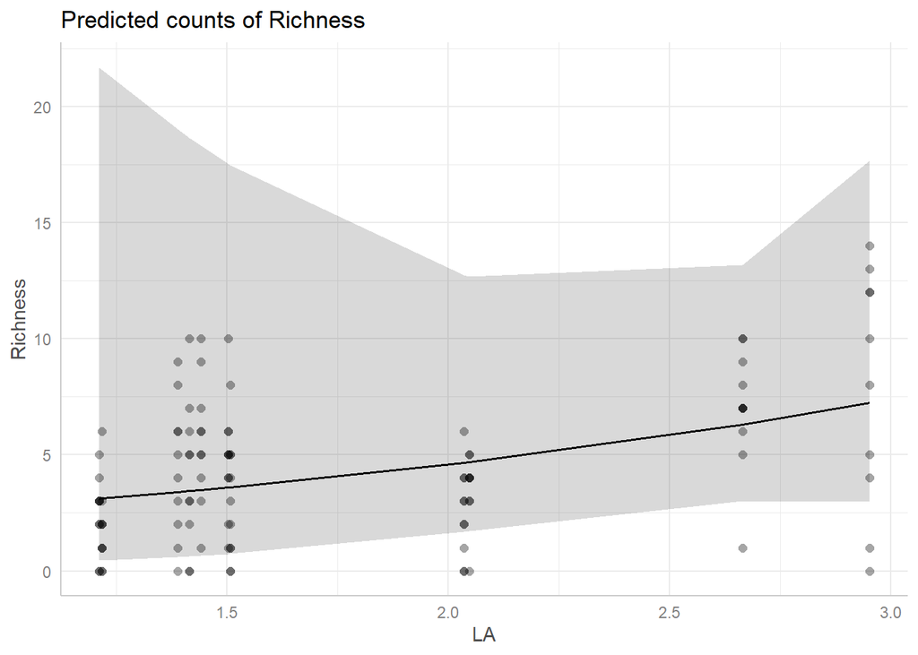

```r
plot(ggpredict(gee_ar1_final), show_data=TRUE)
```

### Summary

1. Start with a biologically motivated mean model and choose a working correlation consistent with your design (AR-1 for time series is common).
2. Fit several structures (AR-1, exchangeable, independence) and compare with QIC.
3. Use simple residual plots for sanity checks; don’t over-interpret them.
4. Report population-averaged effect sizes (e.g., exponentiated coefficients) and discuss robustness.

## 2. Generalized Linear Mixed Model (GLMM)

In this part, we’ll model repeated count data with GLMMs using glmmTMB. Unlike GEE (population-averaged), GLMMs estimate subject-specific effects via random effects and a full likelihood.

Study context (Price et al. 2016):

- Stressors: Mountaintop removal mining with valley fill (MTR/VF) may impact stream ecosystems.
- Organisms: Stream salamanders, which are sensitive to land-use change.
- Design: Counts from 23 headwater streams (sites) — 11 mined, 12 reference. Each stream was sampled 4 times (monthly March–June 2013). Salamanders were identified to species (and sometimes life stage).
- Implication: Repeated measures within sites ⇒ pseudo-replication if ignored. We’ll include a random intercept for site to account for within-site correlation.

### Load and prepare the data

Use the Salamanders data from the glmmTMB package. Key variables we’ll use:

- count: salamander counts
- spp: species (and/or life stage)
- mined: factor indicating mined vs reference site
- site: site ID (random-effect grouping)
- sample: sampling occasion (time ordering within site)

```r
# If not already loaded:
data("Salamanders", package = "glmmTMB")

# Peek
dplyr::glimpse(Salamanders)
```

```
## Rows: 644
## Columns: 9
## $ site   <ord> VF-1, VF-2, VF-3, R-1, R-2, R-3, R-4, R-5, R-6, R-7, VF-4, R-8,…
## $ mined  <fct> yes, yes, yes, no, no, no, no, no, no, no, yes, no, no, no, no,…
## $ cover  <dbl> -1.4423, 0.2984, 0.3979, -0.4476, 0.5968, 1.3428, -0.9450, 0.49…
## $ sample <int> 1, 1, 1, 1, 1, 1, 1, 1, 1, 1, 1, 1, 1, 1, 1, 1, 1, 1, 1, 1, 1, …
## $ DOP    <dbl> -0.596, -0.596, -1.191, 0.000, 0.596, 0.596, -0.596, -0.596, 0.…
## $ Wtemp  <dbl> -1.2294, 0.0848, 1.0142, -3.0234, -0.1443, -0.0147, -0.4469, -0…
## $ DOY    <dbl> -1.497, -1.497, -1.294, -2.712, -0.687, -0.687, -0.970, -0.970,…
## $ spp    <fct> GP, GP, GP, GP, GP, GP, GP, GP, GP, GP, GP, GP, GP, GP, GP, GP,…
## $ count  <int> 0, 0, 0, 2, 2, 1, 1, 2, 4, 1, 0, 0, 1, 0, 0, 0, 0, 1, 0, 0, 0, …
```

```r
summary(Salamanders[, c("count", "spp", "mined", "site", "sample")])
```

```
##      count         spp     mined          site         sample
##  Min.   : 0.0   GP   :92   yes:308   R-1    : 28   Min.   :1.00
##  1st Qu.: 0.0   PR   :92   no :336   R-2    : 28   1st Qu.:1.75
##  Median : 0.0   DM   :92             R-3    : 28   Median :2.50
##  Mean   : 1.3   EC-A :92             R-4    : 28   Mean   :2.50
##  3rd Qu.: 2.0   EC-L :92             R-5    : 28   3rd Qu.:3.25
##  Max.   :36.0   DES-L:92             R-6    : 28   Max.   :4.00
##                 DF   :92             (Other):476
```

```r
# Ensure types we need
Salamanders <- Salamanders %>%
  mutate(
    mined = factor(mined),
    spp   = factor(spp),
    site  = factor(site),
    sample = as.numeric(sample)  # keep a numeric time index for AR1 later
  )
```

### Plot the data

Left: count distributions (you’ll see many zeros). Right: log counts by species and mining status.

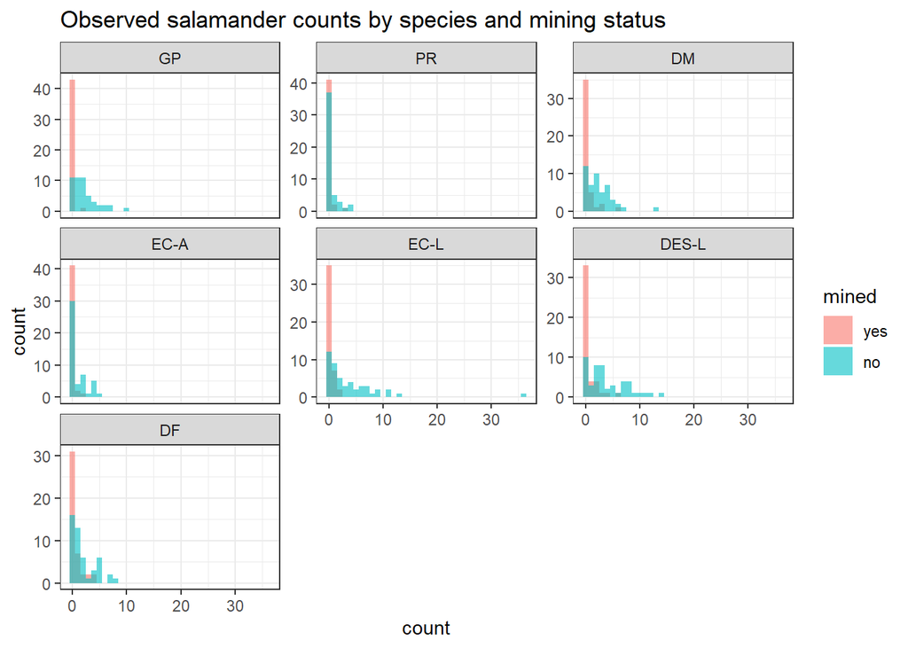

```r
# Histogram with overlay by mining status
Salamanders %>%
  ggplot(aes(count, fill = mined)) +
  geom_histogram(binwidth = 1, alpha = 0.6, position = "identity") +
  facet_wrap(~ spp, scales = "free_y") +
  theme_bw() +
  labs(title = "Observed salamander counts by species and mining status")
```

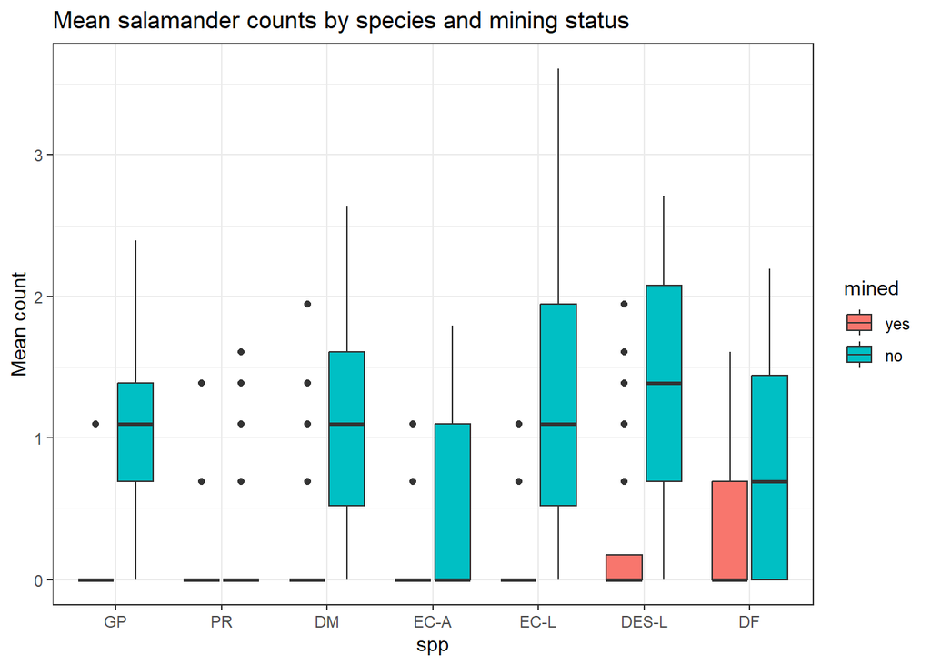

```r
# Counts by species x mining - not that we added a constant and log transformed count
Salamanders %>%
  group_by(spp, mined) %>%
  ggplot(aes(spp, log(count+1), fill = mined)) +
  geom_boxplot() +
  theme_bw() +
  labs(title = "Mean salamander counts by species and mining status",
       y = "Mean count")
```

### Fit a Poisson GLMM with a random intercept for site

```r
poisfit <- glmmTMB(
  count ~ spp * mined + (1 | site),
  family = poisson,
  data = Salamanders
)
summary(poisfit)
```

```
##  Family: poisson  ( log )
## Formula:          count ~ spp * mined + (1 | site)
## Data: Salamanders
##
##      AIC      BIC   logLik deviance df.resid
##     1940     2007     -955     1910      629
##
## Random effects:
##
## Conditional model:
##  Groups Name        Variance Std.Dev.
##  site   (Intercept) 0.332    0.576
## Number of obs: 644, groups:  site, 23
##
## Conditional model:
##                  Estimate Std. Error z value Pr(>|z|)
## (Intercept)        -3.377      0.734   -4.60  4.2e-06 ***
## sppPR               0.916      0.837    1.10  0.27344
## sppDM               2.251      0.743    3.03  0.00246 **
## sppEC-A             0.693      0.866    0.80  0.42349
## sppEC-L             1.705      0.769    2.22  0.02658 *
## sppDES-L            2.526      0.735    3.44  0.00059 ***
## sppDF               2.526      0.735    3.44  0.00059 ***
## minedno             4.111      0.759    5.42  6.0e-08 ***
## sppPR:minedno      -2.489      0.869   -2.86  0.00418 **
## sppDM:minedno      -2.153      0.755   -2.85  0.00438 **
## sppEC-A:minedno    -1.528      0.884   -1.73  0.08385 .
## sppEC-L:minedno    -1.121      0.778   -1.44  0.14967
## sppDES-L:minedno   -1.953      0.745   -2.62  0.00875 **
## sppDF:minedno      -2.667      0.749   -3.56  0.00037 ***
## ---
## Signif. codes:  0 '***' 0.001 '**' 0.01 '*' 0.05 '.' 0.1 ' ' 1
```

```r
tab_model(poisfit)
```

|  | count |  |  |
| --- | --- | --- | --- |
| Predictors | Incidence Rate Ratios | CI | p |
| (Intercept) | 0.03 | 0.01 – 0.14 | **<0.001** |
| spp [PR] | 2.50 | 0.49 – 12.89 | 0.273 |
| spp [DM] | 9.50 | 2.21 – 40.78 | **0.002** |
| spp [EC-A] | 2.00 | 0.37 – 10.92 | 0.423 |
| spp [EC-L] | 5.50 | 1.22 – 24.81 | **0.027** |
| spp [DES-L] | 12.50 | 2.96 – 52.77 | **0.001** |
| spp [DF] | 12.50 | 2.96 – 52.77 | **0.001** |
| mined [no] | 61.00 | 13.79 – 269.89 | **<0.001** |
| spp [PR] × mined [no] | 0.08 | 0.02 – 0.46 | **0.004** |
| spp [DM] × mined [no] | 0.12 | 0.03 – 0.51 | **0.004** |
| spp [EC-A] × mined [no] | 0.22 | 0.04 – 1.23 | 0.084 |
| spp [EC-L] × mined [no] | 0.33 | 0.07 – 1.50 | 0.150 |
| spp [DES-L] × mined [no] | 0.14 | 0.03 – 0.61 | **0.009** |
| spp [DF] × mined [no] | 0.07 | 0.02 – 0.30 | **<0.001** |
| Random Effects |  |  |  |
| σ<sup>2</sup> | 0.44 |  |  |
| τ<sub>00</sub> <sub>site</sub> | 0.33 |  |  |
| ICC | 0.43 |  |  |
| N <sub>site</sub> | 23 |  |  |
| Observations | 644 |  |  |
| Marginal R<sup>2</sup> / Conditional R<sup>2</sup> | 0.735 / 0.849 |  |  |

*Reading the output:*

- Random-effects block shows the variance and SD of the site intercepts (e.g., Var ≈ 0.33 ⇒ SD ≈ 0.575).
- Fixed-effects table shows log-scale coefficients and Wald tests. Wald p-values can be optimistic in small samples; prefer likelihood-based comparison (AIC/LRT) for selection.
- For interpretation on the count scale, exponentiate coefficients for incidence rate ratios (IRRs) or look at the tab_model output.

### Diagnostics with DHARMa

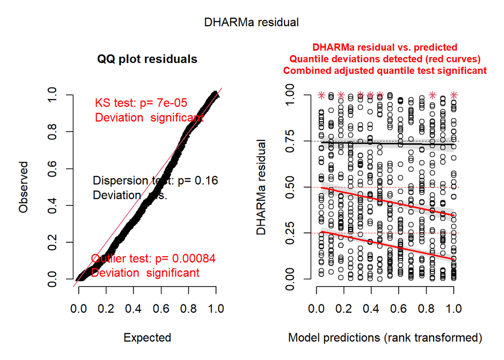

```r
set.seed(1)
res_pois <- simulateResiduals(poisfit)
plot(res_pois)
```

```r
check_overdispersion(res_pois)
```

```
## # Overdispersion test
##
##  dispersion ratio = 1.540
##           p-value =  0.16
```

Don’t over-interpret the formal DHARMa tests: with large n, tiny deviations become “significant”. Scan visually for gross patterns or outliers.

If Poisson is too narrow (variance ≈ mean), use Negative Binomial.

### Dispersion models

We will fit a negative binomial model (nbinom2), which assumes the variance increases quadratically with the mean.

```r
nbfit1 <- glmmTMB(
  count ~ spp * mined + (1 | site),
  family = nbinom2,
  data = Salamanders
)
summary(nbfit1)
```

```
##  Family: nbinom2  ( log )
## Formula:          count ~ spp * mined + (1 | site)
## Data: Salamanders
##
##      AIC      BIC   logLik deviance df.resid
##     1663     1735     -816     1631      628
##
## Random effects:
##
## Conditional model:
##  Groups Name        Variance Std.Dev.
##  site   (Intercept) 0.284    0.533
## Number of obs: 644, groups:  site, 23
##
## Dispersion parameter for nbinom2 family ():    1
##
## Conditional model:
##                  Estimate Std. Error z value Pr(>|z|)
## (Intercept)        -3.375      0.758   -4.45  8.4e-06 ***
## sppPR               0.931      0.877    1.06  0.28883
## sppDM               2.249      0.788    2.85  0.00431 **
## sppEC-A             0.714      0.905    0.79  0.43003
## sppEC-L             1.813      0.813    2.23  0.02574 *
## sppDES-L            2.511      0.779    3.22  0.00128 **
## sppDF               2.576      0.780    3.30  0.00096 ***
## minedno             4.162      0.793    5.25  1.5e-07 ***
## sppPR:minedno      -2.583      0.933   -2.77  0.00562 **
## sppDM:minedno      -2.150      0.826   -2.60  0.00925 **
## sppEC-A:minedno    -1.583      0.946   -1.67  0.09434 .
## sppEC-L:minedno    -1.338      0.849   -1.58  0.11510
## sppDES-L:minedno   -1.936      0.816   -2.37  0.01773 *
## sppDF:minedno      -2.743      0.822   -3.34  0.00084 ***
## ---
## Signif. codes:  0 '***' 0.001 '**' 0.01 '*' 0.05 '.' 0.1 ' ' 1
```

```r
tab_model(nbfit1)
```

|  | count |  |  |
| --- | --- | --- | --- |
| Predictors | Incidence Rate Ratios | CI | p |
| (Intercept) | 0.03 | 0.01 – 0.15 | **<0.001** |
| spp [PR] | 2.54 | 0.45 – 14.16 | 0.289 |
| spp [DM] | 9.47 | 2.02 – 44.37 | **0.004** |
| spp [EC-A] | 2.04 | 0.35 – 12.04 | 0.430 |
| spp [EC-L] | 6.13 | 1.25 – 30.15 | **0.026** |
| spp [DES-L] | 12.32 | 2.67 – 56.76 | **0.001** |
| spp [DF] | 13.15 | 2.85 – 60.66 | **0.001** |
| mined [no] | 64.20 | 13.56 – 303.87 | **<0.001** |
| spp [PR] × mined [no] | 0.08 | 0.01 – 0.47 | **0.006** |
| spp [DM] × mined [no] | 0.12 | 0.02 – 0.59 | **0.009** |
| spp [EC-A] × mined [no] | 0.21 | 0.03 – 1.31 | 0.094 |
| spp [EC-L] × mined [no] | 0.26 | 0.05 – 1.39 | 0.115 |
| spp [DES-L] × mined [no] | 0.14 | 0.03 – 0.71 | **0.018** |
| spp [DF] × mined [no] | 0.06 | 0.01 – 0.32 | **0.001** |
| Random Effects |  |  |  |
| σ<sup>2</sup> | 0.93 |  |  |
| τ<sub>00</sub> <sub>site</sub> | 0.28 |  |  |
| ICC | 0.23 |  |  |
| N <sub>site</sub> | 23 |  |  |
| Observations | 644 |  |  |
| Marginal R<sup>2</sup> / Conditional R<sup>2</sup> | 0.636 / 0.721 |  |  |

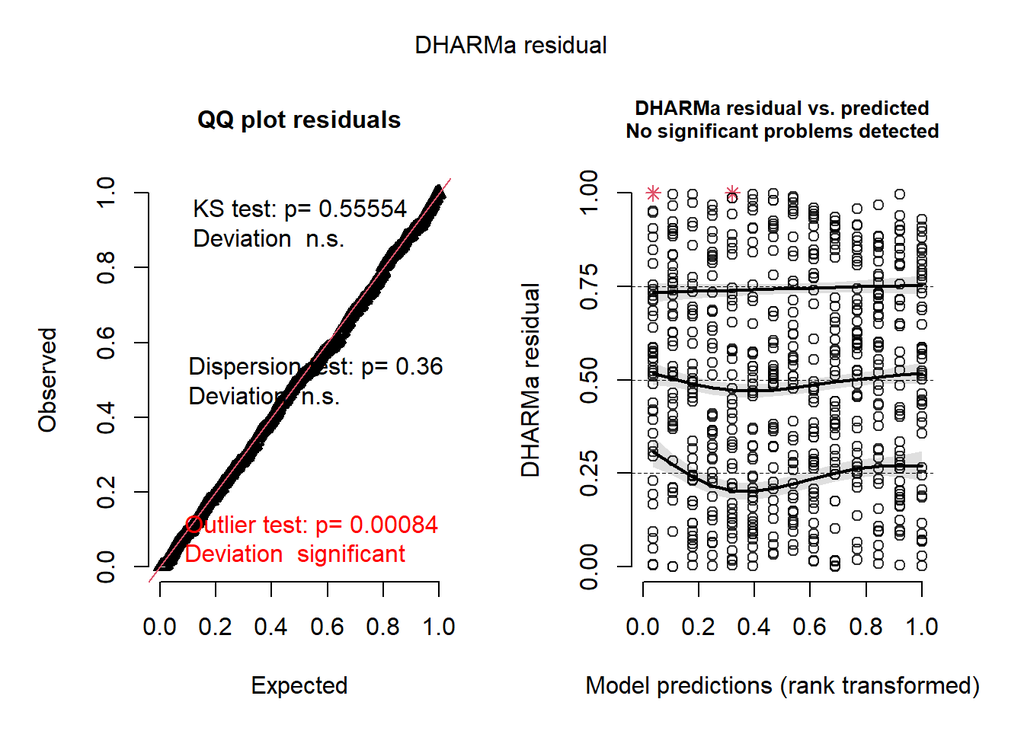

```r
set.seed(1)
plot(simulateResiduals(nbfit1))
```

```r
nbfit_disp <- glmmTMB(
  count ~ spp * mined + (1 | site),
  family = nbinom2,
  dispformula = ~ sample,   # example: allow dispersion to vary by time index
  data = Salamanders
)
AIC(nbfit1, nbfit_disp)
```

```
##            df  AIC
## nbfit1     16 1663
## nbfit_disp 17 1664
```

### Model Selection

Two common routes (often agree):

- drop1() to remove the highest-order interaction via LRT (on ML fits).
- Fit nested candidates and compare by AIC and/or LRT.

```r
# Drop the interaction from the NB model
nbfit_noint <- glmmTMB(count ~ spp + mined + (1 | site),
                       family = nbinom2, data = Salamanders)

AIC(nbfit1, nbfit_noint)
```

```
##             df  AIC
## nbfit1      16 1663
## nbfit_noint 10 1672
```

```r
library(lmtest)
lrtest(nbfit1, nbfit_noint)
```

```
## Likelihood ratio test
##
## Model 1: count ~ spp * mined + (1 | site)
## Model 2: count ~ spp + mined + (1 | site)
##   #Df LogLik Df Chisq Pr(>Chisq)
## 1  16   -816
## 2  10   -826 -6  21.1     0.0018 **
## ---
## Signif. codes:  0 '***' 0.001 '**' 0.01 '*' 0.05 '.' 0.1 ' ' 1
```

If the interaction is retained, interpretation must be interaction-aware (i.e., plot predicted means rather than isolate main effects).

### Plot predictions

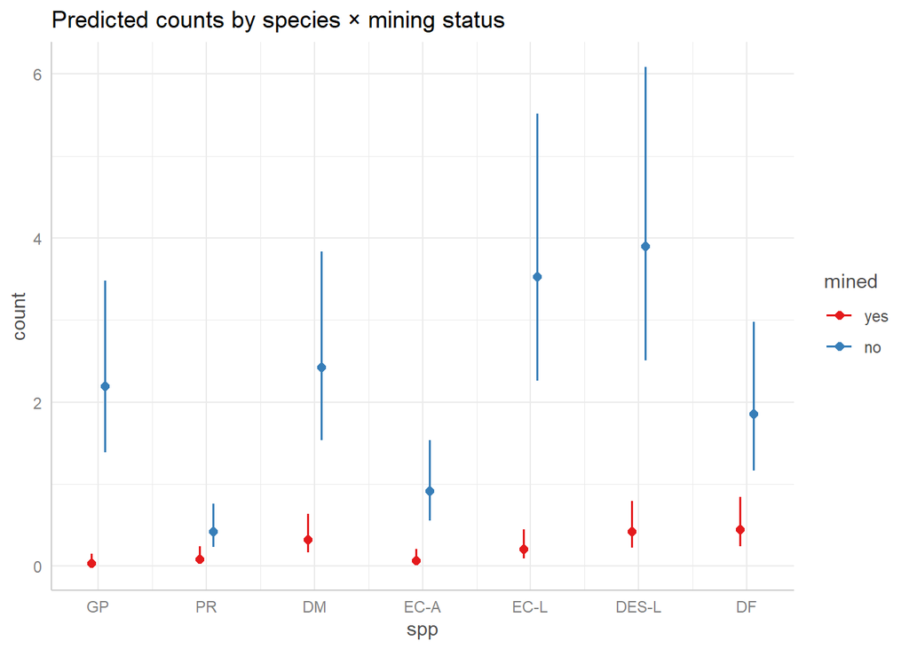

```r
best_nb <- nbfit1

p_counts <- ggpredict(best_nb, terms = c("spp", "mined"))
plot(p_counts) + ggtitle("Predicted counts by species × mining status")
```

Interpretation: Mining reduces salamander counts across species, but the magnitude differs by species (visible as different gaps between mined vs reference within each spp).

### Post-hoc comparisons

Use emmeans for pairwise contrasts by mining within species on the response scale.

```r
library(emmeans)
emm <- emmeans(best_nb, ~ mined | spp, type = "response")
emm
```

```
## spp = GP:
##  mined response    SE  df asymp.LCL asymp.UCL
##  yes       0.03 0.026 Inf     0.008      0.15
##  no        2.20 0.516 Inf     1.386      3.48
##
## spp = PR:
##  mined response    SE  df asymp.LCL asymp.UCL
##  yes       0.09 0.045 Inf     0.031      0.24
##  no        0.42 0.128 Inf     0.232      0.76
##
## spp = DM:
##  mined response    SE  df asymp.LCL asymp.UCL
##  yes       0.32 0.112 Inf     0.165      0.64
##  no        2.43 0.566 Inf     1.535      3.83
##
## spp = EC-A:
##  mined response    SE  df asymp.LCL asymp.UCL
##  yes       0.07 0.040 Inf     0.023      0.21
##  no        0.92 0.240 Inf     0.553      1.54
##
## spp = EC-L:
##  mined response    SE  df asymp.LCL asymp.UCL
##  yes       0.21 0.082 Inf     0.097      0.45
##  no        3.53 0.803 Inf     2.262      5.51
##
## spp = DES-L:
##  mined response    SE  df asymp.LCL asymp.UCL
##  yes       0.42 0.137 Inf     0.223      0.80
##  no        3.90 0.885 Inf     2.505      6.09
##
## spp = DF:
##  mined response    SE  df asymp.LCL asymp.UCL
##  yes       0.45 0.144 Inf     0.241      0.84
##  no        1.86 0.446 Inf     1.162      2.98
##
## Confidence level used: 0.95
## Intervals are back-transformed from the log scale
```

```r
pairs(emm, by = "spp", adjust = "tukey")
```

```
## spp = GP:
##  contrast  ratio     SE  df null z.ratio p.value
##  yes / no 0.0156 0.0124 Inf    1  -5.250  <.0001
##
## spp = PR:
##  contrast  ratio     SE  df null z.ratio p.value
##  yes / no 0.2062 0.1240 Inf    1  -2.630  0.0086
##
## spp = DM:
##  contrast  ratio     SE  df null z.ratio p.value
##  yes / no 0.1337 0.0556 Inf    1  -4.840  <.0001
##
## spp = EC-A:
##  contrast  ratio     SE  df null z.ratio p.value
##  yes / no 0.0758 0.0472 Inf    1  -4.140  <.0001
##
## spp = EC-L:
##  contrast  ratio     SE  df null z.ratio p.value
##  yes / no 0.0594 0.0269 Inf    1  -6.240  <.0001
##
## spp = DES-L:
##  contrast  ratio     SE  df null z.ratio p.value
##  yes / no 0.1079 0.0427 Inf    1  -5.620  <.0001
##
## spp = DF:
##  contrast  ratio     SE  df null z.ratio p.value
##  yes / no 0.2419 0.0966 Inf    1  -3.550  0.0004
##
## Tests are performed on the log scale
```

## Exercises

For both exercises that follow you will use the Owls data set (Owls.csv). These data come from a study of vocal begging behavior in owl nestlings.

Variables you’ll use:

- NCalls: number of calls in 30 s before a parent’s arrival (response)
- BroodSize: number of nestlings (use offset(log(BroodSize)))
- SexParent: sex of visiting parent (factor)
- FoodTreatment: “Deprived” vs “Satiated”
- ArrivalTime: time within the night (numeric/continuous)
- Nest: nest ID (cluster)
- NestNight: grouping factor for “same nest, same night”, e.g. Nest.Dep vs Nest.Sat

```r
# Load data
Owls <- read.csv("../../Data files/Owls.csv")

# Create variables used in the analysis
Owls$NCalls     <- Owls$SiblingNegotiation
Owls$LBroodSize <- log(Owls$BroodSize)
Owls$NestNight  <- factor(ifelse(Owls$FoodTreatment == "Deprived",
                                 paste(Owls$Nest, ".Dep", sep=""),
                                 paste(Owls$Nest, ".Sat", sep="")))
```

### 1. GEE (population-averaged)

1. Plot the data. Make a quick visualization of NCalls vs ArrivalTime and a box/violin plot by FoodTreatment. Briefly describe patterns.
2. Start with a Poisson GLM. Fit NCalls ~ offset(LBroodSize) + SexParent*FoodTreatment + SexParent*ArrivalTime (family = Poisson). Comment on overdispersion using a dispersion statistic or residual plot.
3. Refit with quasipoisson. Test whether each interaction is needed and simplify the model. Report the final formula.
4. Fit GEE with cluster id = Nest and correlation = “exchangeable”. What is the estimated within-nest correlation? Is it plausible?
5. Try AR(1). Fit GEE with cluster id = NestNight and corstr = “ar1”. Compare parameter estimates and SEs to the exchangeable model. Which feels more biologically reasonable here?
6. Compare correlation structures with QIC. Use QIC to compare (a) exchangeable vs (b) AR(1). Which wins? Briefly justify.
7. Starting from the AR(1) model, test the two interactions (Wald tests via anova.geeglm). Reduce to a main-effects model if justified.
8. Interpretation. From your final GEE: interpret the effect of FoodTreatment and ArrivalTime on NCalls. Plot the predicted relationships.

### 2. GLMM (subject-specific)

1. Fit a random-intercept GLMM with NCalls ~ offset(LBroodSize) + SexParent*FoodTreatment + SexParent*ArrivalTime + (1|NestNight) (family = Poisson). Use DHARMa to check residuals; comment on fit.
2. Negative binomial GLMM. Refit with family = nbinom2. Compare AIC and DHARMa plots to the Poisson GLMM.
3. Zero-inflation check. Use DHARMa’s zero-inflation test on your NB model. If indicated, add a constant zero-inflation term (ziformula = ~ 1). Does AIC improve?
4. Model reduction. Use drop1() (LRT/AIC) to remove non-significant interactions and then non-significant main effects (one at a time). State your final model.
5. Interpretation. Report IRRs and percent changes for FoodTreatment and ArrivalTime from your final GLMM.
6. Compare GEE vs GLMM. Do the biological conclusions match? Briefly explain the difference between marginal (GEE) and conditional (GLMM) effects.